# ECG Classification

Zach Quicksall

7/23/2020

## Introduction

Time series classification tasks are becoming more abundant with the ubiquitous existence of smartphones and wearable devices. This notebook illustrates some feature engineering and modeling approaches to classify ECG waveforms that are different from the deep learning approach used in the [publication](https://pubmed.ncbi.nlm.nih.gov/28869899/) from which the data were obtained.

## Load Data

| sample_id | class | X1 | X2 | X3 | X4 | X5 | X6 | X7 | X8 |
| --- | --- | --- | --- | --- | --- | --- | --- | --- | --- |
| TRAIN_1 | 0 | 0.9779412 | 0.9264706 | 0.6813725 | 0.2450980 | 0.1544118 | 0.1911765 | 0.1519608 | 0.0857843 |
| TRAIN_2 | 0 | 0.9601139 | 0.8632479 | 0.4615385 | 0.1965812 | 0.0940171 | 0.1253561 | 0.0997151 | 0.0883191 |
| TRAIN_3 | 0 | 1.0000000 | 0.6594595 | 0.1864865 | 0.0702703 | 0.0702703 | 0.0594595 | 0.0567568 | 0.0432432 |
| TRAIN_4 | 0 | 0.9254144 | 0.6657459 | 0.5414365 | 0.2762431 | 0.1961326 | 0.0773481 | 0.0718232 | 0.0607735 |
| TRAIN_5 | 0 | 0.9671361 | 1.0000000 | 0.8309859 | 0.5868545 | 0.3568075 | 0.2488263 | 0.1455399 | 0.0892019 |
| TRAIN_6 | 0 | 0.9274611 | 1.0000000 | 0.6269430 | 0.1934370 | 0.0949914 | 0.0725389 | 0.0431779 | 0.0535406 |

The above table shows a handful of training instances from the larger data set. The `X` variables are the ECG voltage measurements over time. Let’s dig a bit deeper and generate some visuals.

## Exploratory Data Analysis

### Class Frequency

| class | n | prop |
| --- | --- | --- |
| 0 | 72471 | 0.8277292 |
| 4 | 6431 | 0.0734518 |
| 2 | 5788 | 0.0661078 |
| 1 | 2223 | 0.0253900 |
| 3 | 641 | 0.0073212 |

Given that 82% of instances are of class “0”, training directly on the imbalanced data set will likely lead to a model that blindly assigns the majority class. We will use some sampling techniques to try and address this potential issue.

### ECGs by Class

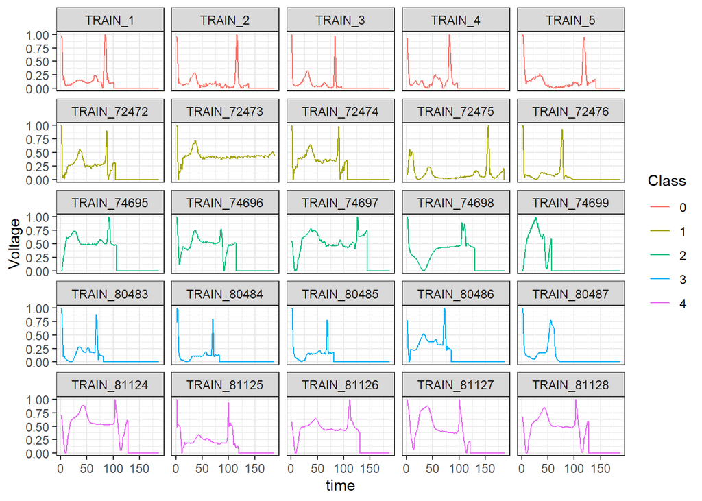

There are clear visual differences between waveforms; both between classes as well as within classes. Let’s compute a variety of features to summarize these waveforms and create a simple tabular data frame for modeling.

## Feature Engineering

| sample_id | class | mean | median | skew | summed_voltage | n_above_mean |
| --- | --- | --- | --- | --- | --- | --- |
| TRAIN_1 | 0 | 0.0984193 | 0.0612745 | 3.5462007 | 18.40441 | 72 |
| TRAIN_10 | 0 | 0.0932637 | 0.0000000 | 3.1748972 | 17.44031 | 65 |
| TRAIN_100 | 0 | 0.3891320 | 0.4797980 | 0.0285321 | 72.76768 | 105 |
| TRAIN_1000 | 0 | 0.0685992 | 0.0000000 | 4.4832951 | 12.82804 | 68 |
| TRAIN_10000 | 0 | 0.1286848 | 0.1234375 | 2.9402132 | 24.06406 | 91 |
| TRAIN_10001 | 0 | 0.2422362 | 0.3165137 | 0.5513905 | 45.29817 | 103 |

In the above table we see some of the features computed from the time series. These include simple summary statistics such as `mean` and `median` as well as some count-based features such as `n_above_mean` which is the number of data points with an above-average voltage. Let’s take a look at the distribution of `mean` by class and see if it looks helpful for differentiating between ECGs.

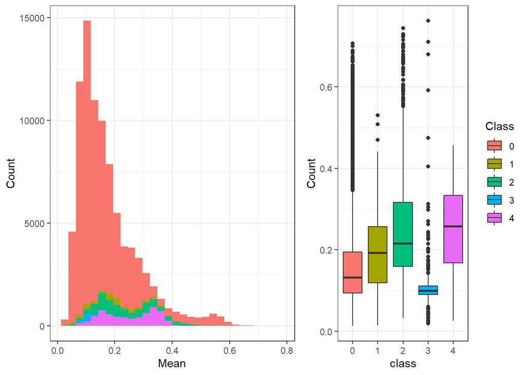

The distributions have substantial overlap but `mean` seems like it will be particularly useful to separate class “3” from the other ECGs. Looking at features in pairs, we see a variety of shapes and relationships which the models will be able to utilize in their classification tasks.

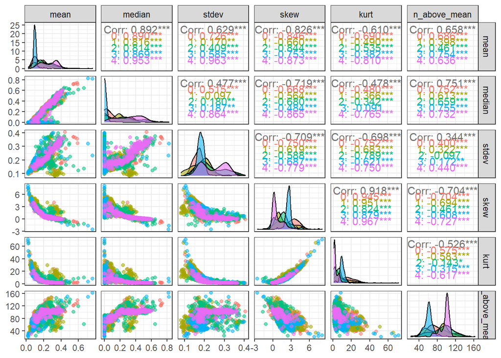

## Modeling

We will use the workflow sets framework from `tidymodels` to train a handful of different models each using two sampling techniques to combat the class imbalance. Model performance assessed via five-fold cross validation can be seen in the figure below.

```r
# Define models

## Logistic regression
lr_mod = multinom_reg(penalty = 0.1) %>%
  set_engine("glmnet") %>%
  set_mode("classification")

## knn
knn_mod = parsnip::nearest_neighbor(neighbors = 9) %>%
  set_engine("kknn") %>%
  set_mode("classification")

## Random forest
rf_mod = rand_forest(trees = 500, mtry = 4) %>%
  set_engine("ranger") %>%
  set_mode("classification")


# Define recipes

## Imbalanced recipe
imbalanced_recipe = recipe(class ~ ., data = train_feature_df) %>%
  update_role(sample_id, new_role = "ID")

# Down sampling recipe
downsampling_recipe = recipe(class ~ ., data = train_feature_df) %>%
  update_role(sample_id, new_role = "ID") %>%
  step_downsample(class)

upsampling_recipe = recipe(class ~ ., data = train_feature_df) %>%
  update_role(sample_id, new_role = "ID") %>%
  step_upsample(class)


# Create workflow set
ecg_set <- workflow_set(preproc = list(Imbalanced = imbalanced_recipe,
                                       Downsampling = downsampling_recipe,
                                       Upsampling = upsampling_recipe),
                        models = list(LR = lr_mod,
                                      KNN = knn_mod,
                                      RF = rf_mod),
                        cross = TRUE)
```

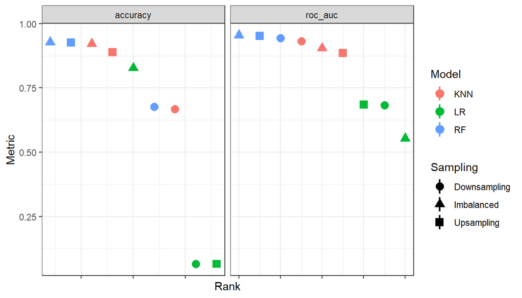

## Evaluation

Based on area under the ROC curve, the random forest models perform best out of the three model types with small differences in performance depending on the sampling strategy applied. Let’s compare the random forest model across the various sampling techniques and see how they impact classification.

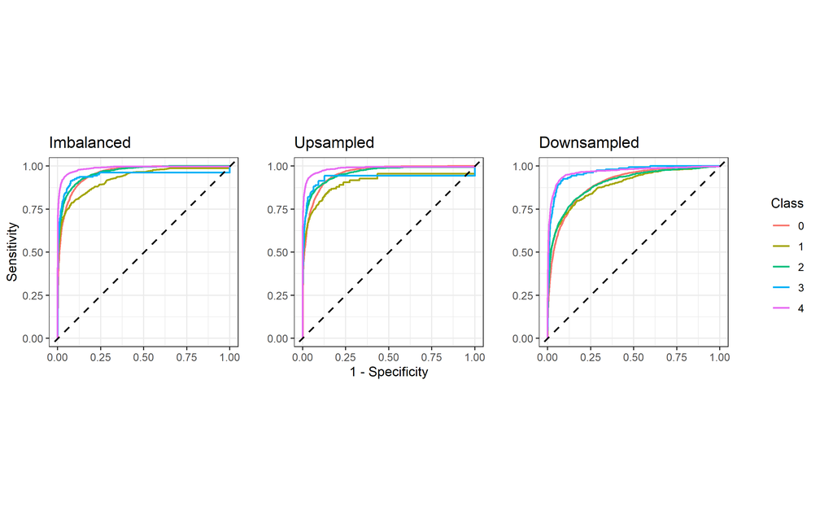

Model performance from the view of ROC curves shows similar behavior in models trained on the unmodified (imbalanced) data set and the up sampled training data set. Down sampling seems to sacrifice performance for select classes.

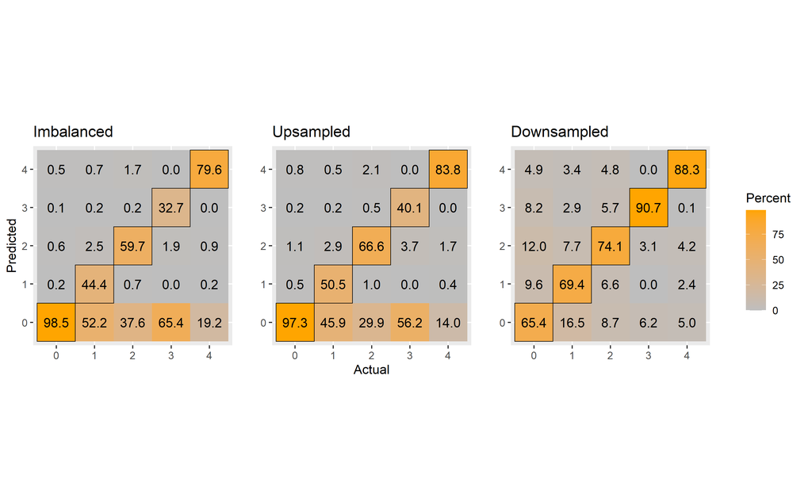

The confusion matrices show strong bias for the majority class in models trained on either the imbalanced data or up sampled data. Accuracy on the rare waveforms is significantly impaired. While the ROC curves on the down sampled data set suggested performance overall, the model effectively classifies the rarer waveforms with better accuracy at the cost of sacrificing performance on the majority class.